# An Introduction to R

Statistics 506, Fall 2018

## About R

As decribed by [The R Foundation](https://www.r-project.org/about.html), “R is a language and environment for statistical computing and graphics.” Importantly, R is open-source, free software distributed under a GNU GPL-3 license.

It is also easily extensible through contributed packages that cover much of modern statistics and data science.

### RStudio

[RStudio](https://www.rstudio.com/) is an “integrated development environment” (IDE) for working with R that simplifies many tasks and makes for a friendlier introduction to R. It provides a nice interface via [Rmarkdown](http://rmarkdown.rstudio.com/) for integrating R code with text for creating documents. RStudio is distributed by a company of the same name that also offers a number of related products for working with data: Shiny for interactive graphics along with enterprise and server editions. I suggest you use RStudio when feasible to streamline your workflow.

## Reading

Everyone should read:

- *R for Data Science*, [Chapter 20](http://r4ds.had.co.nz/vectors.html)
- *Advanced R*, [Chapter 4](https://adv-r.hadley.nz/vectors-chap.html#introduction-2)
  - If you have an earlier edition of the book, read chapter 2 “Vectors”.

Optional reading which may be particularly helpful if you find the above difficult:

- *The Art of R Programming*, Chapters 2-5
- *R for Data Science*, Sections [1.4-1.6](http://r4ds.had.co.nz/introduction.html#prerequisites) and [Chatper 4](http://r4ds.had.co.nz/workflow-basics.html)

## R Basics

### Objects

Nearly everything in **R** is an object that can be referred to by name.

#### Assignment

We generally create objects by assigning values to them:

```r
> # This is a comment ignored by R
> Instructor <- 'Dr. Henderson'
> x <- 10
> y <- 32
> z <- c(x, y) #Form vectors by combining or concatenting elements.
>
> 9 -> w # This works, but is bad style.
> TheAnswer = 42 # Most other languages use = for assignemnt.
```

The values can be referred to by the object name:

```r
> TheAnswer
```

```
## [1] 42
```

##### Naming Objects

Object names can be any syntacticaly [valid](https://stat.ethz.ch/R-manual/R-devel/library/base/html/make.names.html) name. You should, however, avoid clobbering built in `R` names such as `pi`, `mean`, `sum`, etc.

You also should not use [reserved words](https://stat.ethz.ch/R-manual/R-devel/library/base/html/Reserved.html) when naming objects.

You should generally use meaningful, descriptive names for objects you create. There are various styles for creating multi-word object names:

- `snake_case` : separate words with an underscore
- `camelCase` : capitalize subsequent words
- `dot.case` : separate words with a period

##### Non-syntactic names

For purposes of presentation, you may occasionally want to use *non-syntactic names* or names that break the rules above. Use backticks (i.e. `object name`) to create non-synatactic names:

```r
> `Value ($)` = 1e3
> `Value ($)`
```

```
## [1] 1000
```

##### *Style notes*

Generally speaking, you do not need to adopt my coding style. However, you should develop and use a *consistent style* of your own. Still, I do ask you to follow certain common but non-universal style conventions in order to create a cohesive course style. Here are two:

- Please use `=` for standard assignments.
- Please use `snake_case` when [naming objects](https://www.r-bloggers.com/consistent-naming-conventions-in-r/).

#### Value vs Reference

It is important to remember that in **R** objects are typically stored by value and **not** by reference:

```r
> x = 10
> y = 32
> z = c(x, y)
> c(x, y, z)
```

```
## [1] 10 32 10 32
```

```r
> y = TheAnswer
> c(x, y, z)
```

```
## [1] 10 42 10 32
```

In contrast, if `z = c(x,y)` were a reference to the contents of `x` and `y` then changing `y` would change `z` and the value refered to by `z` as well. At a more technical level, *R* has *copy on modify semantics* and uses *lazy evaluation* meaning objects at times are stored by reference. We will learn about these later in the course, but for reasoning about R programs it is generally sufficent to think of objects holding values rather than references.

Later in this lesson we will learn how to create objects without assigning values to them.

#### Global Environment

An environment is a context in which the names we use to refer to **R** objects have meaning. For now, it is sufficient to know that the default environment where objects are assigned is a workspace called the global environment. You can view objects in the global environment using the function `ls()` and remove objects using `rm()`.

```r
> ls()
```

```
## [1] "Instructor" "TheAnswer"  "Value ($)"  "w"          "x"
## [6] "y"          "z"
```

```r
> rm(TheAnswer)
> ls()
```

```
## [1] "Instructor" "Value ($)"  "w"          "x"          "y"
## [6] "z"
```

We can remove multiple objects in a few ways:

```r
> remove(Instructor,TheAnswer) # remove and rm are synonyms
> ls()
```

```
## [1] "Value ($)" "w"         "x"         "y"         "z"
```

```r
> rm(list=c('x','y')) # Object names are passed to list as strings
> ls()
```

```
## [1] "Value ($)" "w"         "z"
```

To clear the entire workspace use ‘rm(list=ls())’:

```r
> ls()
```

```
## [1] "Value ($)" "w"         "z"
```

```r
> rm(list=ls())
> ls()
```

```
## character(0)
```

#### Programmatic assignment

Occasionally, you may write a program where you need to access or assign an object whose name you do not know ahead of time. In these cases you may wish to use the `get()` or `assign()` functions.

```r
> # Ex 1
> rm( list = ls() )
> ls()
```

```
## character(0)
```

```r
> assign("new_int", 9) # i.e. new_int = 9
> ls()
```

```
## [1] "new_int"
```

```r
> get("new_int")
```

```
## [1] 9
```

```r
> # Ex 2
> rm( list = ls() )
> obj = 'obj_name'; val = 42
> assign(obj, value = val) # assign the value in 'val' to the value in 'obj'
> ls()
```

```
## [1] "obj"      "obj_name" "val"
```

```r
> obj
```

```
## [1] "obj_name"
```

```r
> obj_name
```

```
## [1] 42
```

### Arithmetic operations

**R** can do arithmetic with objects that contain numeric types.

```r
> x = 10; y = 32;
> z = x +y
> x + y
```

```
## [1] 42
```

```r
> z / x
```

```
## [1] 4.2
```

```r
> z^2
```

```
## [1] 1764
```

```r
> z + 2*c(y, x) - 10
```

```
## [1] 96 52
```

```r
> 11 %% 2   # Modular arithmetic (i.e. what is the remainder)
```

```
## [1] 1
```

```r
> 11 %/% 2  # Integer division discards the remainder
```

```
## [1] 5
```

Be careful about mixing vectors of different lengths as **R** will generally recycle values:

```r
> x = 4:6
> y = c(0, 1)
> x*y
```

```
## [1] 0 5 0
```

```r
> x = 1:4
> y*x
```

```
## [1] 0 2 0 4
```

There are a number of common mathematical functions already in **R**:

```r
mean(x) # average
sum(x)  # summation
sd(x)   # Standard deviation
var(x)  # Variance
exp(x)  # Exponential
sqrt(x) # Square root
log(x)  # Natural log
sin(x)  # Trigonometric functions
cos(pi/2) # R even contains pi, but only does finite arithmetic
floor(x/2) #The nearest integer below
ceiling(x/2) #The nearest integer above
```

When doing math in **R** or another computing language, be cognizant of the fact that numeric doubles have finite precision. This can sometimes lead to unexpected results as seen here:

```r
> sqrt(2)^2 - 2
```

```
## [1] 4.440892e-16
```

#### Exercises

For each snippet of **R** code below, compute the value of `z` below without using **R**. Use **R** to check your work when done.

1. What is the value of `z`?

```r
x = 10
y = c(9, 9)
z = x
z = y
z = sum(z)
```

2. What is the value of `z`?

```r
x = -1:1
y = rep(1, 10)
z = mean(x*y)
```

3. Which do you think is larger `e0` or `e1`? Why? What is the value of `z`?

```r
> x0 = 1:10000
> y0 = x0*pi/max(x0)
> e0 = sum(  abs( cos(y0)^2 + sin(y0)^2 - 1 ) )
>
> x1 = 1:100000
> y1 = x1*pi/max(x1)
> e1 = sum(  abs( cos(y1)^2 + sin(y1)^2 - 1 ) )
>
> z = floor( e1/e0 )
```

### The **R** package system

Much of the utility of **R** is derived from an extensive collection of user and domain-expert contributed packages. Packages are simply a standardized way for people to share *documented* code and data. There are thousands of packages, likely [more than 10,000](http://blog.revolutionanalytics.com/2017/01/cran-10000.html) officially distributed through the CRAN alone!

Packages are primarily distributed through three sources:

- [CRAN](https://cran.r-project.org/)
- [Github](http://r-pkgs.had.co.nz/git.html)
- [Bioconductor](https://www.bioconductor.org/)

#### Installing packages

The primary way to install a package is using `install.packages("pkg")`.

```r
> #install.packages('lme4') # the package name should be passed as a character string
```

You can find the default location for your **R** packages using the `.libPaths()` function. If you don’t have write permission to this folder, you can set this directory to a personal library instead.

```r
> .libPaths() ## The default library location
```

```
## [1] "/Library/Frameworks/R.framework/Versions/3.4/Resources/library"
```

```r
> .libPaths('/Users/jbhender/Rlib') #Create the directory first!
> .libPaths()
```

```
## [1] "/Users/jbhender/Rlib"
## [2] "/Library/Frameworks/R.framework/Versions/3.4/Resources/library"
```

To install a package to a personal library use the ‘lib’ option.

```r
> ## install.packages("haven",lib='/Users/jbhender/Rlib')
```

Use the above with caution and only when necessary.

If your computer has the necessary tools, packages can also be installed from source by downloading the package file and pointing directly to the source tar ball (‘.tgz’) or Windows binary.

#### Using packages in **R**

- calling `library("pkg")` to add it to the search path,
- using the `pkg::obj` construction to access a package’s exported objects,
- using the `pkg:::obj` to access non-exported objects.

These methods are illustrated below using the data set `InstEval` distributed with the ‘lme4’ package.

```r
> #head(InstEval)
> ## Using the pkg::function construction
> head(lme4::InstEval)
```

```
##   s    d studage lectage service dept y
## 1 1 1002       2       2       0    2 5
## 2 1 1050       2       1       1    6 2
## 3 1 1582       2       2       0    2 5
## 4 1 2050       2       2       1    3 3
## 5 2  115       2       1       0    5 2
## 6 2  756       2       1       0    5 4
```

The `library("pkg")` command adds a package to the search path.

```r
> search()
```

```
## [1] ".GlobalEnv"        "package:stats"     "package:graphics"
## [4] "package:grDevices" "package:utils"     "package:datasets"
## [7] "package:methods"   "Autoloads"         "package:base"
```

```r
> library(lme4)
> search()
```

```
##  [1] ".GlobalEnv"        "package:lme4"      "package:Matrix"
##  [4] "package:stats"     "package:graphics"  "package:grDevices"
##  [7] "package:utils"     "package:datasets"  "package:methods"
## [10] "Autoloads"         "package:base"
```

```r
> head(InstEval)
```

```
##   s    d studage lectage service dept y
## 1 1 1002       2       2       0    2 5
## 2 1 1050       2       1       1    6 2
## 3 1 1582       2       2       0    2 5
## 4 1 2050       2       2       1    3 3
## 5 2  115       2       1       0    5 2
## 6 2  756       2       1       0    5 4
```

To remove a library from the search path use `detach("package:pkg", unload=TRUE)`.

```r
> detach(package:lme4, unload=TRUE)
> search()
```

```
##  [1] ".GlobalEnv"        "package:Matrix"    "package:stats"
##  [4] "package:graphics"  "package:grDevices" "package:utils"
##  [7] "package:datasets"  "package:methods"   "Autoloads"
## [10] "package:base"
```

#### Exercises

1. Find the default location for R packages on:
- your personal computer
- the *scs* servers
2. Install the following R packages (at home):
- [tidyverse](https://www.tidyverse.org/): a collection of packages developed by Hadley Wickham and others
- [data.table](https://github.com/Rdatatable/data.table/wiki): we will use this later in the course and briefly below

### Input and output

**R** is primarily and *in-memory* language, meaning it is designed to work with objects stored in working memory (i.e. *RAM*) rather than on disk. Therefore, it is essential to know how to read and write data from disk.

#### Delimited Data

Data is commonly shared as flat (maybe compressed) text files often delimited by commas (e.g. `.csv`), tab or `'\t'` (e.g. `.tab`, `.txt`), or one+ whitespace characters (e.g. `.data`, `.txt`).

##### Base R

In the base `R` packages, these can be read using `read.table` and its wrappers like `read.csv`. To read the file at `../data/recs2009_public.csv`, use `read.table()` and assign the input to an object.

```r
> recs = read.table( '../data/recs2009_public.csv', sep = ',',
+                    stringsAsFactors = FALSE, header = TRUE)
> dim(recs)
```

```
## [1] 12083   940
```

```r
> class(recs)
```

```
## [1] "data.frame"
```

These functions return `data.frames` which are special *lists* whose memembers all have the same length (i.e. the number of rows.)

Likewise, you can write delimited files using `write.table` or `write.csv`.

```r
> write.table(lme4::InstEval, file = '../data/InstEval.txt', sep = '\t',
+             row.names = FALSE)
```

##### (Tidyverse) readR

The `readR` package distributed with the tidyverse offers a more efficient version of the above with (arguably) better defaults.

```r
> recs_tib = readr::read_delim( '../data/recs2009_public.csv', delim=',')
> dim(recs_tib)
```

```
## [1] 12083   940
```

```r
> class(recs_tib)
```

```
## [1] "tbl_df"     "tbl"        "data.frame"
```

Similary there is a `readr::write_delim` function.

##### data.table

My personal favorite functions for reading and writing delimited data are `data.table::fread()` and `data.table::fwrite()`.

```r
> recs_dt = data.table::fread( '../data/recs2009_public.csv' )
> dim(recs_dt)
```

```
## [1] 12083   940
```

```r
> class(recs_dt)
```

```
## [1] "data.table" "data.frame"
```

You can even pass a command line argument to prepocess your data before reading it in:

```r
> recs_dt = data.table::fread( 'gunzip -c ../data/recs2009_public.csv.gz' )
```

We will learn more about tibbles and data.tables later in the course.

#### Native R Binaries

There are two common formats for writing binaries containing native R objects: `.RData` and `.rds`.

To save one or more R objects to a file, use `save()`.

```r
> df = lme4::InstEval
> df_desc = 'The lme4::InstEval data.'
> save(df, df_desc, file = '../data/InstEval.RData')
```

To restore these objects to the global environment use `load()`.

```r
> rm( list = ls() )
> ls()
```

```
## character(0)
```

```r
> load('../data/InstEval.RData')
> ls()
```

```
## [1] "df"      "df_desc"
```

The function `load()` returns the names of objects returned invisibly meaning you can assign them as shown below.

```r
> foo = load('../data/InstEval.RData')
> foo
```

```
## [1] "df"      "df_desc"
```

```r
> # The following construction assigns the InstEval data to foo.
> # Useful when you don't know what the first object of foo is going to be.
> assign('InstEval', get(foo[1]) )
```

##### Seralized R Data

Generally, it is best to use `save()` and `load()` for R objects. However, there are times when it can be helpful to save the *data* an R object contains without also saving its name. In these cases, you can use `saveRDS()` and `readRDS()`.

```r
> saveRDS(lme4::InstEval, file = '../data/InstEval.rds')
> df = readRDS('../data/InstEval.rds')
```

##### *Style notes*

You may come across the extensions `.Rdata` or `.rda` from time to time. These are generally synonyms for `.RData` and can usually be loaded using `load()`. However, the standard is to use `.RData` and this should be considered course style.

#### Other formats

You may find the following packages useful for reading and writing data from other formats:

- `readxl` for reading Excel file
- `haven` for reading other common data formats
- `foreign` an alternative to `haven` that supports additional format.

### Vectors

The material in this section is largely based on the assigned readings:

- *R for Data Science*, [Chapter 20](http://r4ds.had.co.nz/vectors.html)
- *Advanced R*, [Chapter 4](https://adv-r.hadley.nz/vectors-chap.html#introduction-2)

Vectors are the basic building blocks of many R data structures including rectangular data structures or *data.frames* most commonly used for analysis.

There are two kinds of vectors: *atomic vectors* and *lists*. Every vector has two defining properties aside from the values it holds:

- A *type* (or *mode*) referring to what type of data it holds, and
- A *length* referring to the number of elements it points to.

Use `typeof()` to determine a vector’s type and `length()` to determine its length.

In **R**, *scalars* are just vectors with length one.

#### Atomic Vectors

The elements in atomic vectors must all be of the same *type*. Here are the most important types:

- Logical: `TRUE`, `FALSE`
- Integer: `1L`
- Double: `2.4`
- Character: `"some words"`

Two less commonly used types are *raw* and *complex*. The *mode* of a vector of integers or doubles is *numeric*, the *mode* of other types is the same as the type.

To create new vectors without assigning values to them use `c()` or `vector(mode, length)`.

```r
> cvec = c()
> cvec
```

```r
> length(cvec)
```

```
## [1] 0
```

```r
> typeof(cvec)
```

```
## [1] "NULL"
```

```r
> vvec = vector('character', length = 4)
> length(vvec)
```

```
## [1] 4
```

```r
> typeof(vvec)
```

```
## [1] "character"
```

```r
> vvec
```

```
## [1] "" "" "" ""
```

##### Subsetting

Access elements of a vector `x` using `x[]`. Read about various forms of subsetting in section [20.4.5](http://r4ds.had.co.nz/vectors.html#vector-basics) of *R for Data Science*.

#### Lists

*Lists* provide a more flexible data structure which can hold elements of multiple types, including other vectors. This can be useful for bringing together multiple object types into a single place.

Lists are R’s most flexible object structure.

Read through section 20.5 of *R for Data Science* [here](http://r4ds.had.co.nz/vectors.html#important-types-of-atomic-vector).

Make sure you understand the distinction between `[]` and `[[]]` when subsetting lists.

#### Attributes

Attributes are metadata associated with a vector.

Some of the most important and commonly used attributes we will learn about are:

- names
- class
- dim

Each of these can be accessed and set using functions of the same name.

##### Names

There are a few ways to create a vector with names.

```r
> ## Ex1: assign with names()
> x = 1:3
> names(x) = c('Uno', 'Dos', 'Tres')
> x
```

```
##  Uno  Dos Tres
##    1    2    3
```

```r
> ##Ex2: quoted names
> x = c( 'Uno'=1, 'Dos'=2, 'Tres'=3 )
> x
```

```
##  Uno  Dos Tres
##    1    2    3
```

```r
> ##Ex3: bare names
> x = c( Uno=1, Dos=2, Tres=3)
> x
```

```
##  Uno  Dos Tres
##    1    2    3
```

```r
> ##Ex4:
> names(x)
```

```
## [1] "Uno"  "Dos"  "Tres"
```

##### class

The *class* of an object plays an important role in R’s *S3* object oriented system and determines how an object is treated by various functions.

The class of a vector is generally the same as its *mode* or *type*.

```r
> class(FALSE); class(0L); class(1); class('Two'); class( list() )
```

```
## [1] "logical"
```

```
## [1] "integer"
```

```
## [1] "numeric"
```

```
## [1] "character"
```

```
## [1] "list"
```

Note the difference after we change the *class* of *x*.

```r
> x
```

```
##  Uno  Dos Tres
##    1    2    3
```

```r
> class(x) = 'character'
> print(x)
```

```
##  Uno  Dos Tres
##  "1"  "2"  "3"
```

It’s generally better to use explicit conversion functions such as `as.character()` to change an object’s class as simplying modifyin the attribute will not guarantee the object is a valid member of that class.

##### dim

We use `dim()` to access or set the *dimensions* of an object. Three special classes where dimensions matter are *matrix*, *array*, and *data.frame*. We will examine just the first two here.

Both matrices and arrays are really just long vectors with this additional *dim* attribute.

```r
> # Matrix class
> x = matrix(1:10, nrow = 5, ncol = 2)
> dim(x)
```

```
## [1] 5 2
```

```r
> class(x)
```

```
## [1] "matrix"
```

```r
> dim(x) = c(2, 5)
> x
```

```
##      [,1] [,2] [,3] [,4] [,5]
## [1,]    1    3    5    7    9
## [2,]    2    4    6    8   10
```

The above demonstrates that **R** matrices are stored in *column-major order*. Matrices are the two-dimensional special cases of arrays.

```r
> dim(x) = c(5,1,2)
> class(x)
```

```
## [1] "array"
```

```r
> x
```

```
## , , 1
##
##      [,1]
## [1,]    1
## [2,]    2
## [3,]    3
## [4,]    4
## [5,]    5
##
## , , 2
##
##      [,1]
## [1,]    6
## [2,]    7
## [3,]    8
## [4,]    9
## [5,]   10
```

```r
> dim(x) = c(5,2,1)
> x
```

```
## , , 1
##
##      [,1] [,2]
## [1,]    1    6
## [2,]    2    7
## [3,]    3    8
## [4,]    4    9
## [5,]    5   10
```

```r
> class(x)
```

```
## [1] "array"
```

##### Arbitrary attributes

See a list of all attributes associated with a vector using `attributes()`. Access and assign specific attributes using `attr()`.

```r
> # Assign an a new attribute color
> attr(x, 'color') = 'green'
> attributes(x)
```

```
## $dim
## [1] 5 2 1
##
## $color
## [1] "green"
```

```r
> class( attributes(x) )
```

```
## [1] "list"
```

```r
> # Access or assign specific attributes
> attr(x, 'dim')
```

```
## [1] 5 2 1
```

```r
> attr(x, 'dim') = c(5, 2)
> class(x)
```

```
## [1] "matrix"
```

```r
> x
```

```
##      [,1] [,2]
## [1,]    1    6
## [2,]    2    7
## [3,]    3    8
## [4,]    4    9
## [5,]    5   10
## attr(,"color")
## [1] "green"
```

```r
> # Assign NULL to remove attributes
> attr(x, 'color') = NULL
> attributes(x)
```

```
## $dim
## [1] 5 2
```

### The *data.frame* class

The *data.frame* class in **R** is a *list* whose elements (columns) all have the same length. A *data.frame* has attributes *names* with elements of the list constituting its columns, *row.names* with values uniquely identifying each row, and has *class* *data.frame*.

Construct a new *data.frame* using `data.frame()`. Here is an example.

```r
> df =
+   data.frame(
+     ID = 1:10,
+     Group = sample(0:1, 10, replace=TRUE),
+     Var1 = rnorm(10),
+     Var2 = seq(0, 1, length.out=10),
+     Var3 = rep(c('a', 'b'), each=5)
+   )
>
> names(df)
```

```
## [1] "ID"    "Group" "Var1"  "Var2"  "Var3"
```

```r
> dim(df)
```

```
## [1] 10  5
```

```r
> length(df)
```

```
## [1] 5
```

```r
> nrow(df)
```

```
## [1] 10
```

```r
> class(df$Var3)
```

```
## [1] "factor"
```

We can access the values of a data frame both like a list:

```r
> df$ID
```

```
##  [1]  1  2  3  4  5  6  7  8  9 10
```

```r
> df[['Var3']]
```

```
##  [1] a a a a a b b b b b
## Levels: a b
```

or like a matrix

```r
> df[1:5,]
```

```
##   ID Group       Var1      Var2 Var3
## 1  1     0 -0.6369388 0.0000000    a
## 2  2     1  0.6034539 0.1111111    a
## 3  3     0 -1.1611500 0.2222222    a
## 4  4     0 -0.9597248 0.3333333    a
## 5  5     1  0.7657235 0.4444444    a
```

```r
> df[,'Var2']
```

```
##  [1] 0.0000000 0.1111111 0.2222222 0.3333333 0.4444444 0.5555556 0.6666667
##  [8] 0.7777778 0.8888889 1.0000000
```

Read more about data frames in *Advanced R* [here](http://adv-r.had.co.nz/Data-structures.html#data-frames).

##### Exercises

Consider an abritrary *data.frame* `df` with columns `a`, `b`, and `c`.

1. Which of the following is not the same as the others?
   1. `df$a`
   2. `df[1]`
   3. `df[['a']]`
   4. `df[,1]`
2. Which of the following are equivalent to `length(df)`? Choose all that apply.
   1. `nrow(df)`
   2. `ncol(df)`
   3. `3*nrow(df)`
   4. `length(df[['a']])`
   5. `length(df[1:3])`
3. Which of the following are equivalent to `length(df$a)`? Choose all that apply.
   1. `nrow(df)`
   2. `ncol(df)`
   3. `3*nrow(df)`
   4. `length(df[['a']])`
   5. `length(df[1:3])`

### Logicals

**R** has three reserved words of type ‘logical’:

```r
> typeof(TRUE)
```

```
## [1] "logical"
```

```r
> typeof(FALSE)
```

```
## [1] "logical"
```

```r
> typeof(NA)
```

```
## [1] "logical"
```

```r
> if ( TRUE && T ) {
+   print('Synonyms')
+ }
```

```
## [1] "Synonyms"
```

```r
> if ( FALSE || F ){
+   print('Synonyms')
+ }
```

While ‘T’ and ‘F’ are equivalent to ‘TRUE’ and ‘FALSE’ it is best to always use the full words. You should also avoid using ‘T’ or ‘F’ as names for objects or function arguments.

##### Boolean comparisons

Boolean operators are useful for generating values conditionally on other values. Here are the basics:

| Operator | Meaning |
| --- | --- |
| `==` | equal |
| `!=` | not equal |
| `>`, `>=` | greater than (or equal to) |
| `<`, `<=` | less than (or equal to) |
| `&&` | scalar AND |
| `\|\|` | scalar OR |
| `&` | vectorized AND |
| `\|` | vectorized OR |
| `!` | negation (`!TRUE == FALSE` and `!FALSE == TRUE`) |
| `any()` | are ANY of the elements true |
| `all()` | are ALL of the elements true |

Logicals are created by Boolean comparisons:

```r
> {2*3} == 6     # test equality with ==
```

```
## [1] TRUE
```

```r
> {2+2} != 5     # use != for 'not equal'
```

```
## [1] TRUE
```

```r
> sqrt(70) > 8   # comparison operators: >, >=, <, <=
```

```
## [1] TRUE
```

```r
> sqrt(64) >= 8
```

```
## [1] TRUE
```

```r
> !{2==3}        # Use not to negate or 'flip' a logical
```

```
## [1] TRUE
```

Comparison operators are vectorized:

```r
> 1:10 > 5
```

```
##  [1] FALSE FALSE FALSE FALSE FALSE  TRUE  TRUE  TRUE  TRUE  TRUE
```

You can can combine operators using ‘and (&&)’ or ‘or (||)’:

```r
> {2+2}==4 | {2+2}==5 # An or statement asks if either statement is true
```

```
## [1] TRUE
```

```r
> {2+2}==4 & {2+2}==5 # And requires both to be true
```

```
## [1] FALSE
```

Note the difference between the single and double versions:

```r
> even = {1:10 %% 2} == 0
> div4 = {1:10 %% 4} == 0
>
> even | div4
```

```
##  [1] FALSE  TRUE FALSE  TRUE FALSE  TRUE FALSE  TRUE FALSE  TRUE
```

```r
> even || div4
```

```
## [1] FALSE
```

```r
> even & div4
```

```
##  [1] FALSE FALSE FALSE  TRUE FALSE FALSE FALSE  TRUE FALSE FALSE
```

```r
> even && div4
```

```
## [1] FALSE
```

Use `any` or `all` to efficiently check for the presence of any `TRUE` or `FALSE`.

```r
> any(even)
```

```
## [1] TRUE
```

```r
> all(even)
```

```
## [1] FALSE
```

#### Using which

The `which()` function returns the elements of a logical vector that return true:

```r
> which( {1:5}^2 > 10 )
```

```
## [1] 4 5
```

A combination of `which` and logicals can be used to subset data frames:

```r
> head(mtcars)
```

```
##                    mpg cyl disp  hp drat    wt  qsec vs am gear carb
## Mazda RX4         21.0   6  160 110 3.90 2.620 16.46  0  1    4    4
## Mazda RX4 Wag     21.0   6  160 110 3.90 2.875 17.02  0  1    4    4
## Datsun 710        22.8   4  108  93 3.85 2.320 18.61  1  1    4    1
## Hornet 4 Drive    21.4   6  258 110 3.08 3.215 19.44  1  0    3    1
## Hornet Sportabout 18.7   8  360 175 3.15 3.440 17.02  0  0    3    2
## Valiant           18.1   6  225 105 2.76 3.460 20.22  1  0    3    1
```

```r
> mtcars[ which( mtcars$mpg>30 ), ]
```

```
##                 mpg cyl disp  hp drat    wt  qsec vs am gear carb
## Fiat 128       32.4   4 78.7  66 4.08 2.200 19.47  1  1    4    1
## Honda Civic    30.4   4 75.7  52 4.93 1.615 18.52  1  1    4    2
## Toyota Corolla 33.9   4 71.1  65 4.22 1.835 19.90  1  1    4    1
## Lotus Europa   30.4   4 95.1 113 3.77 1.513 16.90  1  1    5    2
```

### Functions

**R** identifies functions by the ‘func()’ construction. Functions are simply collections of commands that do something. Functions take *arguments* which can be used to specify *which* objects to operate on and *what* values of parameters are used. You can use ‘help(func)’ to see what a function is used for and what arguments it expects, i.e. `help(sprintf)`.

#### Arguments

Functions will often have multiple arguments. Some arguments have default values, others do not. All arguments without default values must be passed to a function. Arguments can be passed by name or position. For instance,

```r
> x = runif( n=5, min=0, max=1)
> y = runif(5, 0, 1)
> z = runif(5)
> round( cbind(x, y, z), 1)
```

```
##        x   y   z
## [1,] 0.3 0.7 0.5
## [2,] 0.4 0.1 0.1
## [3,] 0.1 0.5 0.8
## [4,] 0.8 1.0 0.6
## [5,] 1.0 0.9 0.1
```

both generate 5 numbers from a Uniform(0,1) distribution.

Arguments passed by name need not be in order:

```r
> w = runif(min=0, max=1, n=5)
> u = runif(min=0, max=1, 5) # This also works but is bad style.
> round( rbind(u=u, w=w), 1 )
```

```
##   [,1] [,2] [,3] [,4] [,5]
## u  0.5  0.1  0.9  0.1  0.2
## w  0.0  0.4  0.2  0.6  0.7
```

#### Writing Functions

You can create your own functions in **R**. Use functions for tasks that you repeat often in order to make your scripts more easily readable and modifiable. A good rule of thumb is never to copy an paste more than twice; use a function instead. It can also be a good practice to use functions to break complex processes into parts, especially if these parts are used with control flow statements such as loops or conditionals.

```r
> # function to compute z-scores
> zScore1 = function(x){
+   xbar = mean(x)
+   s = sd(x)
+   z = (x - mean(x)) / s
+   return(z)
+ }
```

The return statement is not strictly necessary, but can make complex functions more readable. It is good practice to avoid creating intermediate objects to store values only used once.

```r
> # function to compute z-scores
> zScore2 = function(x){
+   {x - mean(x)} / sd(x)
+ }
```

```r
> x = rnorm(10,3,1) ## generate some normally distributed values
> round( cbind(x, 'Z1' = zScore1(x), 'Z2' = zScore2(x) ), 1)
```

```
##         x   Z1   Z2
##  [1,] 2.1 -1.4 -1.4
##  [2,] 2.7 -0.5 -0.5
##  [3,] 3.4  0.6  0.6
##  [4,] 3.6  0.8  0.8
##  [5,] 3.8  1.2  1.2
##  [6,] 1.8 -1.8 -1.8
##  [7,] 2.7 -0.5 -0.5
##  [8,] 3.0 -0.1 -0.1
##  [9,] 3.6  0.8  0.8
## [10,] 3.5  0.7  0.7
```

#### Default parameters

We can set default values for parameters using the construction ‘parameter = xx’ in the function definition.

```r
> # function to compute z-scores
> zScore3 = function(x, na.rm=T){
+   {x - mean(x, na.rm=na.rm)} / sd(x, na.rm=na.rm)
+ }
```

```r
> x = c(NA, x, NA)
> round( cbind(x, 'Z1' = zScore1(x), 'Z2' = zScore2(x), 'Z3' = zScore3(x) ), 1)
```

```
##         x Z1 Z2   Z3
##  [1,]  NA NA NA   NA
##  [2,] 2.1 NA NA -1.4
##  [3,] 2.7 NA NA -0.5
##  [4,] 3.4 NA NA  0.6
##  [5,] 3.6 NA NA  0.8
##  [6,] 3.8 NA NA  1.2
##  [7,] 1.8 NA NA -1.8
##  [8,] 2.7 NA NA -0.5
##  [9,] 3.0 NA NA -0.1
## [10,] 3.6 NA NA  0.8
## [11,] 3.5 NA NA  0.7
## [12,]  NA NA NA   NA
```

#### Scope

Scoping refers to how **R** looks up the value associated with an object referred to by name. There are two types of scoping – lexical and dynamic – but we will concern ourselves only with lexical scoping here. There are four keys to understanding scoping:

- environments
- name masking
- variables vs functions
- dynamic lookup and lazy evaluation.

An environment can be thought of as context in which a name for an object makes sense. Each time a function is called, it generates a new environment for the computation.

Consider the follwing examples:

```r
> ls()
```

```
##  [1] "cvec"     "df"       "df_desc"  "div4"     "even"     "foo"
##  [7] "InstEval" "u"        "vvec"     "w"        "x"        "y"
## [13] "z"        "zScore1"  "zScore2"  "zScore3"
```

```r
> f1 = function(){
+   f1_message = "I'm defined inside of f!"  # `message` is a function in base
+   ls()
+ }
> f1()
```

```
## [1] "f1_message"
```

```r
> exists('f1')
```

```
## [1] TRUE
```

```r
> exists('f1_message')
```

```
## [1] FALSE
```

```r
> environment()
```

```
## <environment: R_GlobalEnv>
```

```r
> f2 = function(){
+   environment()
+ }
> f2()
```

```
## <environment: 0x7f84b0adff58>
```

```r
> rm(f1, f2)
```

Name masking refers to where and in what order **R** looks for object names.  
When we call `f1` above, **R** first looks in the current environment which happens to be the global environment. The call to `ls()` however, happens within the environment created by the function call and hence returns only the objects defined in the local environment.

When an environment is created, it gets nested within the current environment referred to as the “parent environemnt”. When an object is referenced we first look in the current environment and move recursively up through parent environments until we find a value bound to that name.

Name masking refers to the notion that objects of the same name can exist in different environments. Consider these examples:

```r
> y = x = 'I came from outside of f!'
> f3 = function(){
+   x =  'I came from inside of x!'
+   list( x=x, y=y )
+ }
> f3()
```

```
## $x
## [1] "I came from inside of x!"
##
## $y
## [1] "I came from outside of f!"
```

```r
> x
```

```
## [1] "I came from outside of f!"
```

```r
> mean = function(x){ sum(x) }
> mean(1:10)
```

```
## [1] 55
```

```r
> base::mean(1:10)
```

```
## [1] 5.5
```

```r
> rm(mean)
```

**R** also uses dynamic lookup, meaning values are searched for when a function is called and not when it is created. In the example above, `y` was defined in the global environment rather than within the function body. This means the value returned by `f3` depends on the value of `y` in the global environment. You should generally avoid this, but there are occasions where it can be useful.

```r
> y = "I have been reinvented!"
> f3()
```

```
## $x
## [1] "I came from inside of x!"
##
## $y
## [1] "I have been reinvented!"
```

Finally, lazy evaluation means **R** only evaluates function arguments if/when they are actually used.

```r
> f4 = function(x){
+   #x
+   45
+ }
>
> f4( x=stop("Let's pass an error.") )
```

```
## [1] 45
```

Uncomment `x` to see what happens if we evlauate it.

#### Resources

Read more about functions [here](http://r4ds.had.co.nz/functions.html) and [here](http://adv-r.had.co.nz/Functions.html#lazy-evaluation).

The second link is to Chapter 6 from the optional text “Advanced R”.

You can also read much more about functions in Chapter 7 of “The Art of R Programming.”

#### Practice

1. Access and skim the help pages for ‘median()’, ‘mad()’, and ‘IQR’.
2. Write a function ‘zScoreRobust’ that accepts a numeric vector and returns robust z-scores.
3. Make the function you wrote robust to vectors containing “NA” values
4. Generate some data from N(4,2) to test your functions.

### Control Statments

#### for loops

Here is the syntax for a basic for loop in **R**

```r
> for ( i in 1:10 ) {
+    cat(i, '\n')
+ }
```

```
## 1
## 2
## 3
## 4
## 5
## 6
## 7
## 8
## 9
## 10
```

Note that the loop and the *iterator* are evaluated within the global environment.

```r
> for ( var in names(mtcars) ) {
+   cat( sprintf('average %s = %4.3f', var, mean(mtcars[,var]) ), '\n')
+ }
```

```
## average mpg = 20.091
## average cyl = 6.188
## average disp = 230.722
## average hp = 146.688
## average drat = 3.597
## average wt = 3.217
## average qsec = 17.849
## average vs = 0.438
## average am = 0.406
## average gear = 3.688
## average carb = 2.812
```

```r
> var
```

```
## [1] "carb"
```

#### while

A `while` statement can be useful when you aren’t sure how many iterations are needed.  
Here is an example that takes a random walk and terminates if the value is more than 10 units from 0.

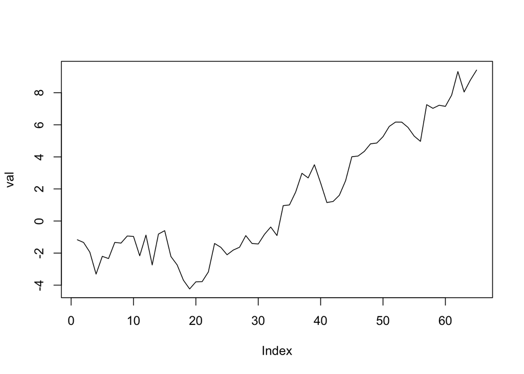

```r
> maxIter = 1e3 # always limit the total iterations allowed
> val = vector( mode = 'numeric', length = maxIter)
> val[1] = rnorm(1) ## intialize
>
> k = 1
> while ( abs(val[k]) < 10 & k <= maxIter ) {
+   val[k+1] = val[k] + rnorm(1)
+   k = k + 1
+ }
> val = val[1:{k-1}]
>
> plot(val, type='l')
```

#### key words

The following key words are useful within loops:

- `break` - break out of the currently excuting loop
- `next` - move to the next iteration immediately, without executing the rest of this iteration (`continue` in other languages such as C++)

Here is an example using `next`:

```r
> for ( i in 1:10 ) {
+   if ( i %% 2 == 0 ) next
+   cat(i,'\n')
+ }
```

```
## 1
## 3
## 5
## 7
## 9
```

Here is an example using `break`:

```r
> x = c()
> for ( i in 1:1e1 ) {
+   if ( i %% 3 == 0 ) break
+   x = c(x,i)
+ }
> print(x)
```

```
## [1] 1 2
```

##### Exercises

The Fibonacci sequence starts 1, 1, 2, … and continues with each new value formed by adding the two previous values.

1. Write a function ‘Fib1’ which takes an argument ‘n’ and returns the $n^{th}$ value of the Fibonacci sequence. Use a for loop in the function.
2. Write a function ‘Fib2’ which does the same thing using a while loop.
3. Use a switch to write a function that has a parameter `loop = c('for', 'while')` for calling either `Fib1` or `Fib2`.

### Conditionals

In programming, we often need to execute a piece of code only if some condition is true. Here are some of the **R** tools for doing this.

#### if statements

The workhorse for conditional execution in **R** is the `if` statement. In the syntax below, note the spacing around the condtion enclosed in the parantheses.

```r
> if ( TRUE ) {
+   print('do something if true')
+ }
```

```
## [1] "do something if true"
```

There are different opions on whether to use the above or this:

```r
> if( TRUE ){
+   print('do something if true')
+ }
```

```
## [1] "do something if true"
```

You can choose a style of your choosing, but be *consistent*. Occasionally, with short statements it can be idomatic to include the condition on the same line without the braces:

```r
> if( TRUE ) print('do something if true')
```

```
## [1] "do something if true"
```

Use an `else` to control the flow without separately checking the conditon’s negation:

```r
> if ( {2+2}==5 ) {
+   print('the statement is true')
+ } else {
+   print('the statement is false')
+ }
```

```
## [1] "the statement is false"
```

```r
> result = c(4, 5)
> report = ifelse( {2 + 2}==result, 'true', 'false')
> report
```

```
## [1] "true"  "false"
```

As you can see above, there is also an `ifelse()` function that can be useful.

For more complex cases, you may want to check multiple condtions:

```r
> a = -1
> b = 1
>
> if ( a*b > 0 ) {
+   print('Zero is not between a and b')
+ } else if ( a < b ) {
+     smaller = a
+     larger = b
+ } else {
+     smaller = b
+     larger  = a
+ }
>
> c(smaller, larger)
```

```
## [1] -1  1
```

##### *Style notes*

In all of the examples above, please pay close attention to the use of indentation for clariy. Also note that the opening brace for a conditional expression should start on the same line as the `if` statement.

#### switch

Use a switch when you have mulitple discrete options.

Here is a simple example:

```r
> cases = function(x) {
+   switch(as.character(x),
+     a=1,
+     b=2,
+     c=3,
+     "Neither a, b, nor c."
+   )
+ }
> cases("a")
```

```
## [1] 1
```

```r
> cases("m")
```

```
## [1] "Neither a, b, nor c."
```

```r
> cases(8)
```

```
## [1] "Neither a, b, nor c."
```

Without the coercion, the final call will evaluate to `NULL`.

```r
> cases2 = function(x) {
+   switch(x,
+     a=1,
+     b=2,
+     c=3,
+     "Neither a, b, nor c."
+   )
+ }
> cases2_output = cases2(8)
> cases2_output
```

[output not shown]

A `switch` can also be used with a numeric expression,

```r
> for( i in c(-1:3, 9) )  print( switch(i, 1, 2, 3, 4) )
```

```
## NULL
## NULL
## [1] 1
## [1] 2
## [1] 3
## NULL
```

Here is a more useful example:

```r
> mySummary =function(x){
+
+   switch(class(x),
+          factor=table(x),
+          numeric=sprintf('mean=%4.2f,sd=%4.2f', mean(x), sd(x)),
+           'Only defined for factor and numeric classes.')
+
+ }
>
> for ( var in names(iris) ) {
+   cat(var, ':\n', sep='')
+   print( mySummary(iris[,var]) )
+ }
```

```
## Sepal.Length:
## [1] "mean=5.84,sd=0.83"
## Sepal.Width:
## [1] "mean=3.06,sd=0.44"
## Petal.Length:
## [1] "mean=3.76,sd=1.77"
## Petal.Width:
## [1] "mean=1.20,sd=0.76"
## Species:
## x
##     setosa versicolor  virginica
##         50         50         50
```

##### Exercises

1. Read the R code below and determine the value of `twos` and `threes` at the end.

```r
twos = 0
threes = 0
for ( i in 1:10 ) {
  if ( i %% 2 == 0 ) {
    twos = twos + i
  } else if ( i %% 3 == 0 ) {
    threes = threes + i
  }
}
```

2. Read the **R** code below and determine the value of `x` at the end.

```r
x = 0
for ( i in 1:10 ) {
  x = x + switch(1 + {i %% 3}, 1, 5, 10)
}
```